# Task 4

Hannes Guth

2023-03-13

```r
library(data.table) # package to use data in data tables
library(fpp2) # package for the holt method
library(fpp3) # package that includes the dataset
library(Metrics) # package that contains the rmse-function
library(ggplot2) # package to create plots
```

## Belgium

### 1.

#### Plot the Exports series for selected country and discuss the main features of the data.

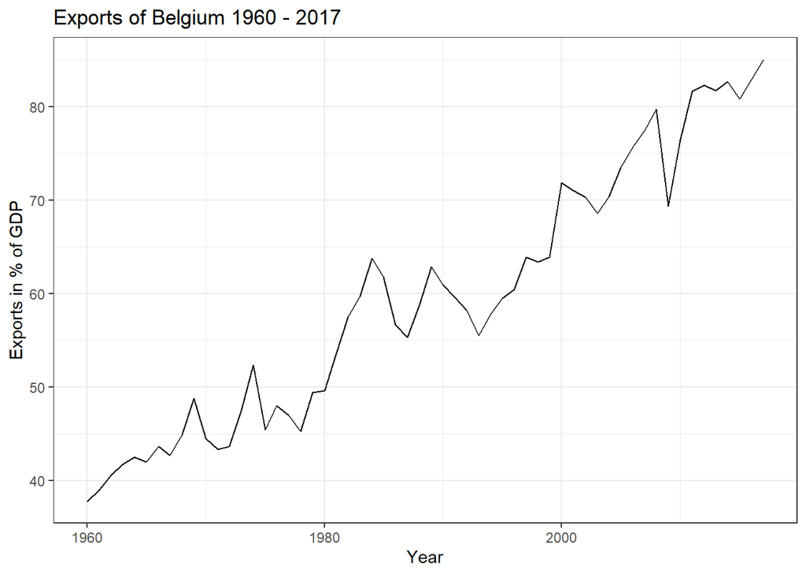

```r
global_economy_dt = data.table(global_economy) # transform the data set into a data table
belgium = global_economy_dt[Country == "Belgium",] # only select the obsevartions for Belgium

ggplot(belgium, aes(x = Year, y = Exports, group = 1)) + # create a new ggplot with the data from Belgium, Year in the x-axis and the exports on the y-axis
  geom_line() + # create a line chart
  theme_bw() + # use the theme bw
  labs(title = "Exports of Belgium 1960 - 2017", y = "Exports in % of GDP")
```

The data exist from 1960 onwards. One cannot observe any seasonality or cycles but overall a positive, linear trend. The data represent the export in % of GDP. The minimum was in 1960 with approximately 37%-38% and the maximum was reached in 2017 with 85%.

### 2.

#### Use one of the viewed methods (simple exponential smoothing, Holt, Holt-Winter) which is appropriated to your series. Justify your choice. Comment on your model’s parameter(s). How well does your model fit the data?

```r
first_model = holt(belgium$Exports, alpha = 0.3, beta = 0.3, initial = "optimal", h = 1) # run the first model with arbitrarily chosen values for the smoothing parameters and 1 period forecast

# create new data table with the years, the true exports and the forecasted exports the first model
rmse_table = data.table("Year" = belgium$Year,
                       "True_Exports" = belgium$Exports,
                       "Forecasted_Exports" = first_model$fitted)

mean(rmse_table$True_Exports) # calculate the mean of the true exports
```

```
## [1] 59.55855
```

```r
rmse(rmse_table$True_Exports, rmse_table$Forecasted_Exports) # calculate the RMSE
```

```
## [1] 4.101693
```

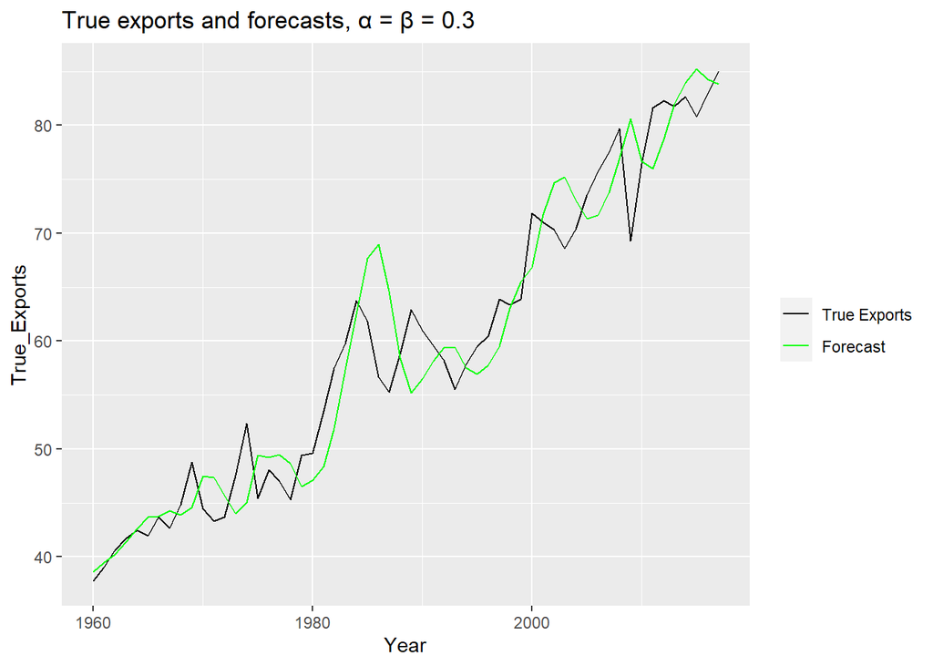

```r
ggplot(rmse_table, aes(x = Year), group = 1) + # create a new ggplot with the data from the rmse table and Year on the x-axis
  geom_line(aes(y = True_Exports, color = "True Exports")) + # one line for the true exports
  geom_line(aes(y = Forecasted_Exports, color = "Forecast")) + # one line for the forecast
  labs(title = "True exports and forecasts, α = β = 0.3 ") + # set the labels
  scale_color_manual(values = c("True Exports" = "black", "Forecast" = "green")) + # set the colors
  theme(legend.title = element_blank()) # remove the legend title
```

The graph shows that the forecast follows roughly the true exports, 1 period delayed. The RMSE is 4.1 what is 6.9% of the true export values’ mean.

### 3.

##### Run model with different values of the parameter(s). Plot it against parameter(s) values. How each parameter does impact the forecast?

#### Different parameters

##### Influence of the parameters $\alpha$ and $\beta$ on the model

Following the equations, the Forecast is the sum of the previous level and the previous trend. $\alpha$ has a positive impact on the forecast, given a fixed $y_t$ and no effect on the trend. $\beta$ positively enhances the effect of the difference of the level of current period and the level of the previous period, the current trend and negatively influences the effect of the previous trend.

##### Plotting different combinations of paramters

To improve the result from 2., one can try to vary the smoothing parameters $\alpha$ and $\beta$. In the following, a sequence of graphs will be created that show the forecast against the true value and give information about the corresponding smoothing parameters and achieved RMSE. The $\alpha$ value will be varied on the left side and the $\beta$ value on the right side.

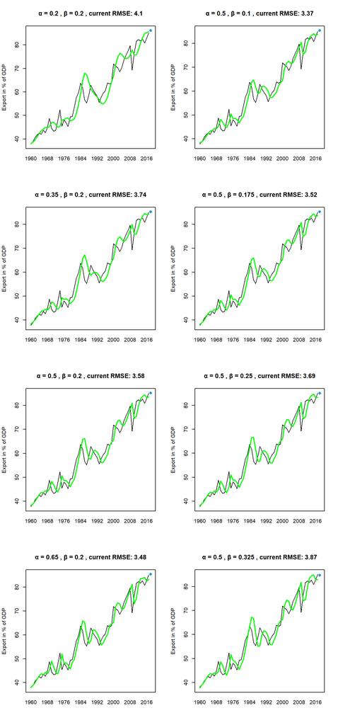

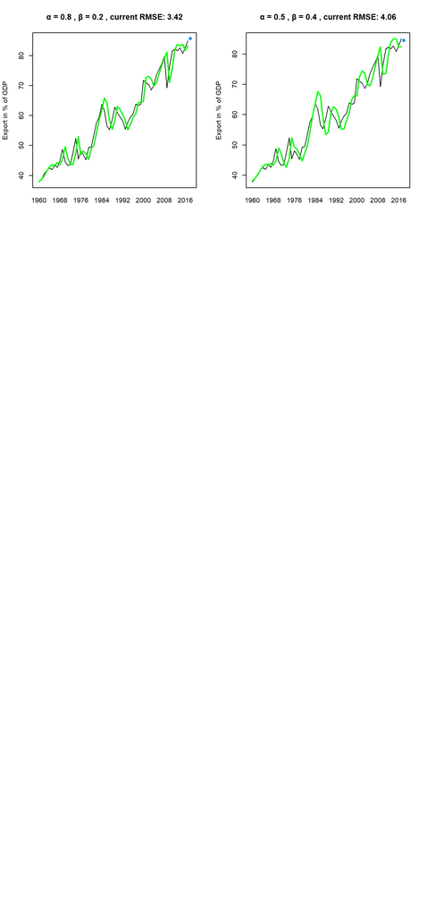

```r
par(mfrow=c(4,2)) # set the arrangement of the plots
for (i in seq(0.20, 0.90, 0.15)){ # set the sequence that shall be executed to vary the smoothing parameters
  for (j in 1:2){ # to arrange the plots in two "columns"
    if (j == 1){ # in the first column
      current_model = holt(belgium$Exports, alpha = i, beta = 0.2, initial = "optimal", h = 1) # create a Holt's model with varying alpha and fixed beta
      current_rmse = rmse(rmse_table$True_Exports, current_model$fitted) # calculate the RMSE of the model
      plot(current_model, main = print(paste("α =", i, ", β =",0.2, ", current RMSE:", round(current_rmse, 2))), PI = FALSE, xaxt='n', ylab = "Export in % of GDP") # plot the corresponding graph with the true values
      axis(1, at=1:58, labels= belgium$Year, tck = 0) # edit the axis labels
      lines(fitted(current_model), lwd=2, col="green") # add the line with the prediction in green
    }
    if (j == 2){ # as above but now with a varying beta that shall not be bigger than alpha
      current_model = holt(belgium$Exports, alpha = 0.5, beta = i/2, initial = "optimal", h = 1)
      current_rmse = rmse(rmse_table$True_Exports, current_model$fitted)
      plot(current_model, main = print(paste("α =", 0.5, ", β =", i/2, ", current RMSE:", round(current_rmse, 2))), PI = FALSE, xaxt='n', ylab = "Export in % of GDP")
      axis(1, at=1:58, labels= belgium$Year, tck = 0) # edit the axis labels
      lines(fitted(current_model), lwd=2, col="green") # add the line with the prediction in green
    }
  }
}
```

#### Best parameter combination

In this abstract, the optimal parameter combination will be searched.

```r
# create a new data table to store year, the true export value and the forecast value of the respectively current model that will be calculated during this approach
current_table = data.table("Year" = belgium$Year,
                       "True_Exports" = belgium$Exports,
                       "Forecasted_Exports" = 0)

# create a new data table to store the values of the RSME and the corresponding parameters
parameters_table = data.table("alpha" = numeric(4950),
                              "beta" = numeric(4950),
                              "RMSE" = numeric(4950),
                              "forecast" = numeric(4950))

# set the values for the parameters and the best RMSE to initial values which will be overwritten during the approach
a = 0
b = 0
best_rmse = 100
counter = 0

for (i in 1:100){ # create a loop for the alphas
  for (j in 1:100){ # create a loop for the betas
    a = i/100 # calculate the current alpha
    b = j/100 # calculate the current beta
    if (a >= b & a < 1){ # if alpha >= beta and alpha < 0 (otherwise errors will be given)
      current_model = holt(belgium$Exports, alpha = a, beta = b, initial = "optimal", h = 1) # create a current model with the respective current parameters
      # fill the parameters table with the data about the parameters and the resulting RMSE
      counter = counter + 1
      parameters_table[counter, 1] = as.double(a)
      parameters_table[counter, 2] = as.double(b)
      parameters_table[counter, 3] = as.double(rmse(current_table$True_Exports, current_table$Forecasted_Exports))
      #z[i,j] = as.double(rmse(current_table$True_Exports, current_table$Forecasted_Exports))
      current_table$Forecasted_Exports = current_model$fitted # update the forecasts in the current table
      if (rmse(current_table$True_Exports, current_table$Forecasted_Exports) < best_rmse){ # if a better RMSE could have been achieved
        best_rmse = rmse(current_table$True_Exports, current_table$Forecasted_Exports) # set this RMSE as the new best RMSE
        best_a = a # update the currently best alpha
        best_b = b # update the currently best beta
      }
    }
  }
}

# show the finally retrieved best values for the RMSE and the smoothing parameters
best_rmse
```

```
## [1] 3.097425
```

```r
best_a
```

```
## [1] 0.73
```

```r
best_b
```

```
## [1] 0.01
```

### 4.

#### Provide forecast for 5 steps ahead. Does your prediction look good? Please, explain.

To enlarge the prediction to 5 periods, h has to be changed to 5. All other parameters stay the same. The previously obtained “optimal” values for $\alpha$ and $\beta$ will be kept.

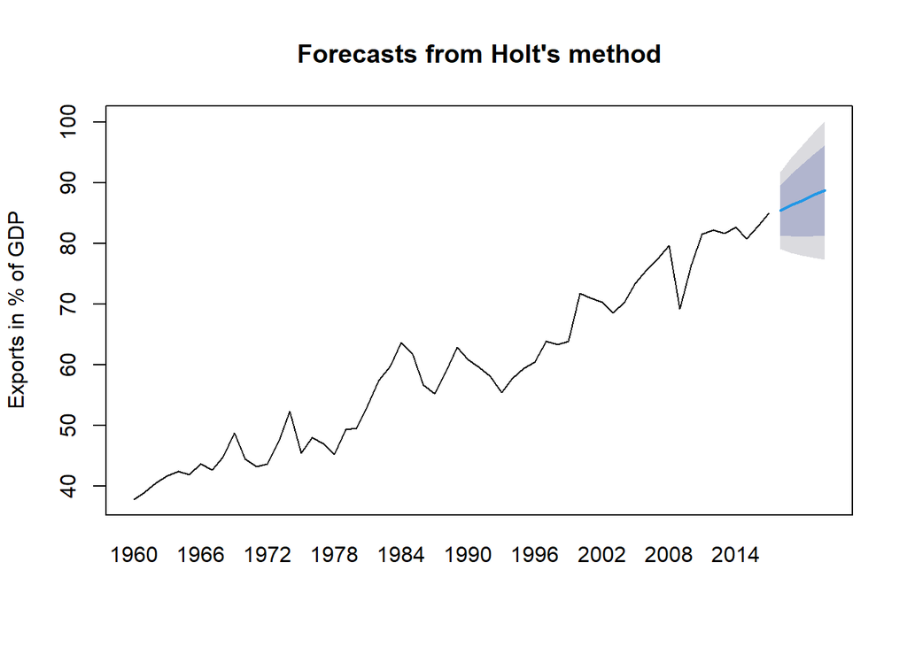

```r
five_step_model = holt(belgium$Exports, alpha = best_a, beta = best_b, initial = "optimal", h = 5) # use the holt function to obtain a model that forecasts 5 periods
rmse_table$Forecasted_Exports = five_step_model$fitted # update the RMSE-table

plot(five_step_model, xaxt = "n", ylab = "Exports in % of GDP") # show the model with the 5 periods forecast
axis(1, at=1:58, labels = belgium$Year, tck = 0) # edit the axis labels
```

The forecast for the next 5 periods reflects the previously positive trend since the blue line has a positive slope. From the confidence interval in greyscale, one can see that there is rising uncertainty the further one goes into the future. This interval seems to be reasonable from looking at the data.

## Bonus task: Cameroon

### 1.

#### Plot the Exports series for selected country and discuss the main features of the data.

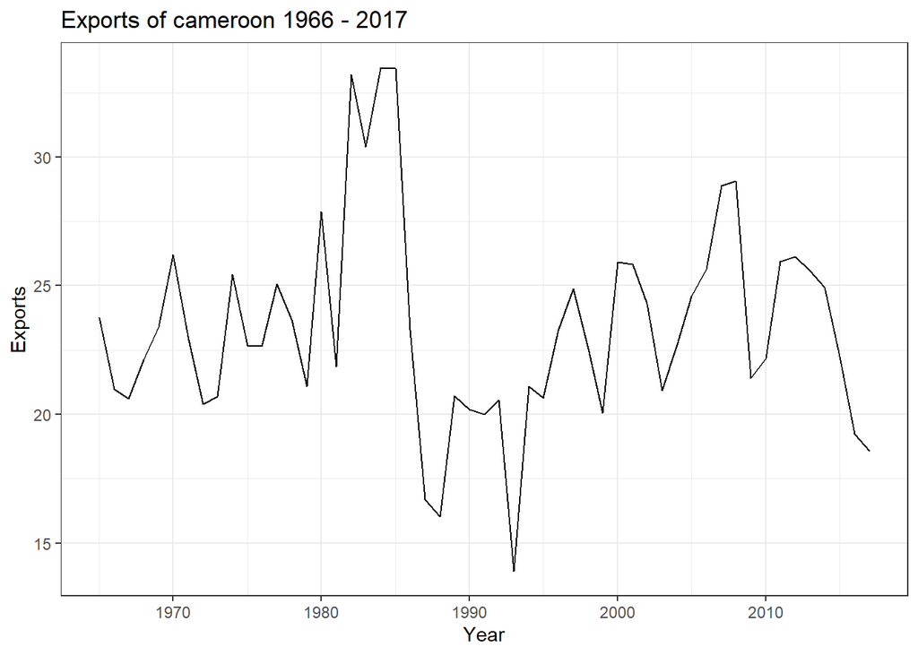

```r
global_economy_dt = data.table(global_economy) # transform the data set into a data table
cameroon = global_economy_dt[Country == "Cameroon",] # only select the observations for Cameroon
cameroon = cameroon[6:58,] # remove NAs

ggplot(cameroon, aes(x = Year, y = Exports, group = 1)) + # create a new ggplot with the data from Cameroon, Year in the x-axis and the exports on the y-axis
  geom_line() + # create a line chart
  theme_bw() + # use the theme bw
  labs(title = "Exports of cameroon 1966 - 2017") # edit the title
```

### 2.

#### Use one of the viewed methods (simple exponential smoothing, Holt, Holt-Winter) which is appropriate to your series. Justify your choice. Comment on your model’s parameter(s). How well does your model fit the data?

The method that seems to be appropriate here is the SES method because of the absence of a clear trend and seasonality.

```r
first_model = ses(cameroon$Exports, alpha = 0.3, initial = "simple", h = 1) # run the first model with an arbitrarily chosen value for alpha and 1 period forecast

# create new data table with the years, the true exports and the forecasted exports the first model
rmse_table = data.table("Year" = cameroon$Year,
                       "True_Exports" = cameroon$Exports,
                       "Forecasted_Exports" = first_model$fitted)

mean(rmse_table$True_Exports) # calculate the mean
```

```
## [1] 23.39533
```

```r
rmse(rmse_table$True_Exports, rmse_table$Forecasted_Exports) # calculate the RMSE
```

```
## [1] 3.861979
```

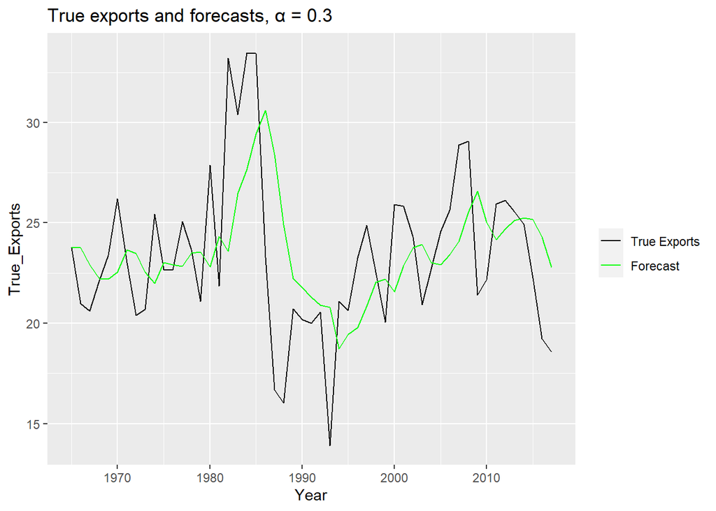

```r
ggplot(rmse_table, aes(x = Year), group = 1) + # create a new ggplot with the data from the rmse table and Year on the x-axis
  geom_line(aes(y = True_Exports, color = "True Exports")) + # one line for the true exports
  geom_line(aes(y = Forecasted_Exports, color = "Forecast")) + # one line for the forecast
  labs(title = "True exports and forecasts, α = 0.3 ") + # set the labels
  scale_color_manual(values = c("True Exports" = "black", "Forecast" = "green")) + # set the colors
  theme(legend.title = element_blank()) # remove the legend title
```

The graph shows that the forecast follows roughly the true exports, 1 period delayed. The RMSE is 3.86 what is roughly 15% of the true export values. This error is bigger than the one which was observed with the Holt model for the Belgium.

### 3.

##### Run model with different values of the parameter(s). Plot it against parameter(s) values. How each parameter does impact the forecast?

#### Different parameters

##### Plotting for different values of $\alpha$

In the following, different graphs for different $\alpha$s will be printed to show the effect of $\alpha$ on the forecast.

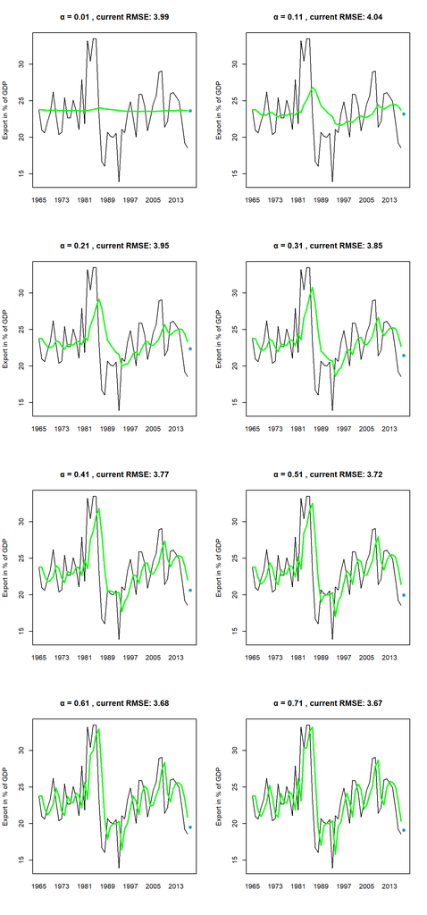

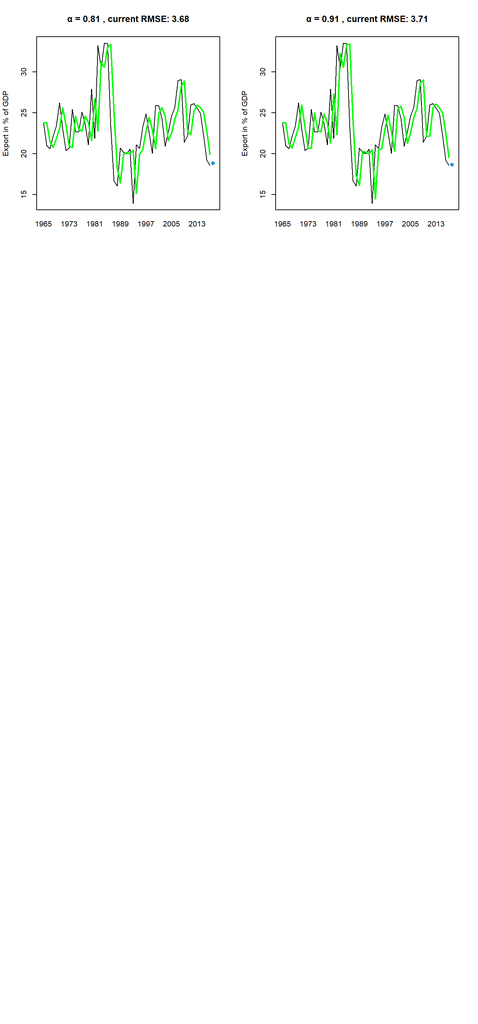

```r
par(mfrow=c(4,2)) # set the arrangement of the plots
for (i in seq(0.01, 0.99, 0.1)){ # set the sequence that shall be executed to vary the smoothing parameter
      current_model = ses(cameroon$Exports, alpha = i, initial = "simple", h = 1) # create an SES model with varying alpha and fixed beta
      current_rmse = rmse(rmse_table$True_Exports, current_model$fitted) # calculate the RMSE of the model
      plot(current_model, main = print(paste("α =", i, ", current RMSE:", round(current_rmse, 2))), PI = FALSE, xaxt = 'n', ylab = "Export in % of GDP") # plot the corresponding graph with the true values
      axis(1, at = 1:53, labels = cameroon$Year, tck = 0) # edit the axis labels
      lines(fitted(current_model), lwd = 2, col="green") # add the line with the prediction in green
}
```

#### Best parameter combination

In this abstract, the optimal $\alpha$ will be searched.

```r
# create a new data table to store year, the true export value and the forecast value of the respectively current model that will be calculated during this approach
current_table = data.table("Year" = cameroon$Year,
                       "True_Exports" = cameroon$Exports,
                       "Forecasted_Exports" = 0)

parameters_table = data.table("alpha" = numeric(4950),
                              "RMSE" = numeric(4950),
                              "forecast" = numeric(4950))

# set the values for the parameters and the best RMSE to initial values which will be overwritten during the approach
a = 0
best_rmse = 100
counter = 0

for (i in 1:100){ # create a loop for the alphas
  a = i/100 # calculate the current alpha
  current_model = ses(cameroon$Exports, alpha = a, initial = "simple", h = 1) # create a current model with the respective current alpha
  # fill the parameters table with the data about the parameters and the resulting RMSE
  counter = counter + 1
  parameters_table[counter, 1] = as.double(a)
  parameters_table[counter, 2] = as.double(rmse(current_table$True_Exports, current_table$Forecasted_Exports))
  current_table$Forecasted_Exports = current_model$fitted # update the forecasts in the current table
  if (rmse(current_table$True_Exports, current_table$Forecasted_Exports) < best_rmse){ # if a better RMSE could have been achieved
    best_rmse = rmse(current_table$True_Exports, current_table$Forecasted_Exports) # set this RMSE as the new best RMSE
    best_a = a # update the currently best alpha
  }
}

# show the finally retrieved best values for the RMSE and the smoothing parameters
best_rmse
```

```
## [1] 3.669365
```

```r
best_a
```

```
## [1] 0.72
```

The optimal $\alpha$ is 0.72 and that leads to an RMSE of 3.67, what is slightly better than the one with the arbitrarily chosen $\alpha$.

### 4.

#### Provide forecast for 5 steps ahead. Does your prediction look good? Please, explain.

To enlarge the prediction to 5 periods, h has to be changed to 5. All other parameters stay the same. The previously obtained “optimal” value for $\alpha$ will be kept.

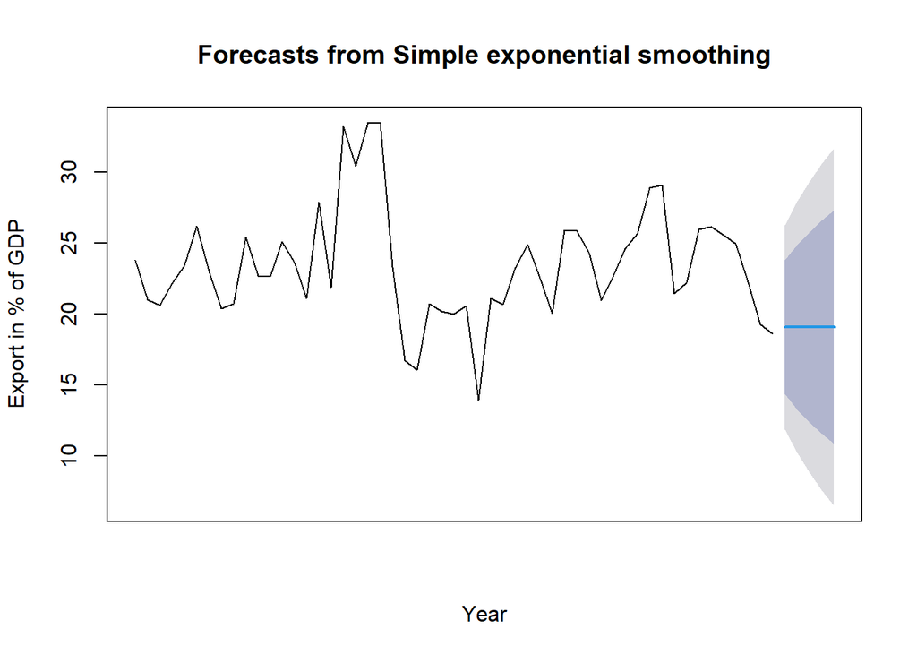

```r
five_step_model = ses(cameroon$Exports, alpha = best_a, initial = "simple", h = 5) # use the ses function to obtain a model that forecasts 5 periods
rmse_table$Forecasted_Exports = five_step_model$fitted # update the RMSE-table

plot(five_step_model, xaxt = 'n', xlab = "Year", ylab = "Export in % of GDP") # show the model with the 5 periods forecast
```

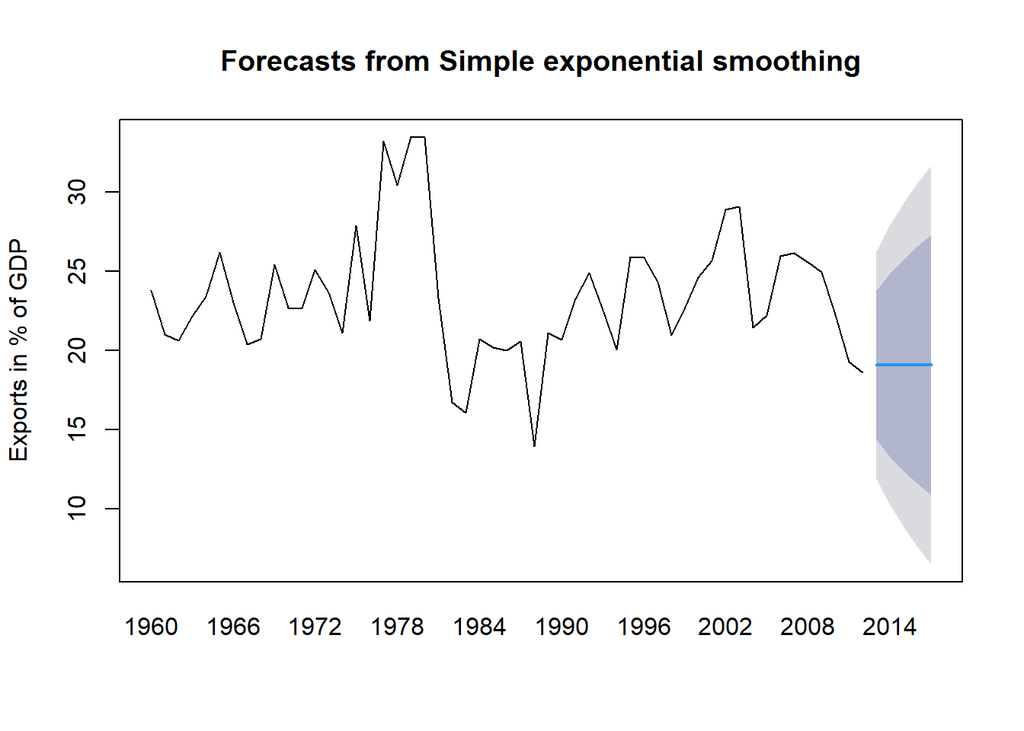

```r
plot(five_step_model, xaxt = "n", ylab = "Exports in % of GDP") # show the model with the 5 periods forecast
axis(1, at=1:58, labels = belgium$Year, tck = 0) # edit the axis labels
```

The forecast for the next 5 periods reflects that there is no trend since the blue line of the confidence interval is approximately horizontal. The confidence interval seems to be estimated too low because the majority of data lays above the blue line. Basically one single observation from the previous data would have fallen into the lowest 2.5% of the interval while there were a few which would have fallen in or even above the highest 2.5%.

## References

### Packages

Dowle M, Srinivasan A (2021). *data.table: Extension of `data.frame`*. R package version 1.14.2, https://CRAN.R-project.org/package=data.table.

Hyndman R (2023). *fpp2: Data for “Forecasting: Principles and Practice” (2nd Edition)*. R package version 2.5, https://CRAN.R-project.org/package=fpp2.

Hyndman R (2023). *fpp3: Data for “Forecasting: Principles and Practice” (3rd Edition)*. R package version 0.5, https://CRAN.R-project.org/package=fpp3.

Hamner B, Frasco M (2018). *Metrics: Evaluation Metrics for Machine Learning*. R package version 0.1.4, https://CRAN.R-project.org/package=Metrics.

H. Wickham. ggplot2: Elegant Graphics for Data Analysis. Springer-Verlag New York, 2016.